# Potvin and Schutz

## Part 5

**Credit for the non-centrality parameter for the interaction goes to Andrew Vigotsky** ### 2x2 ANOVA, within design

Potvin & Schutz (2000) simulate a wide range of repeated measure designs. They give an example of a 3x3 design, with the following correlation matrix:

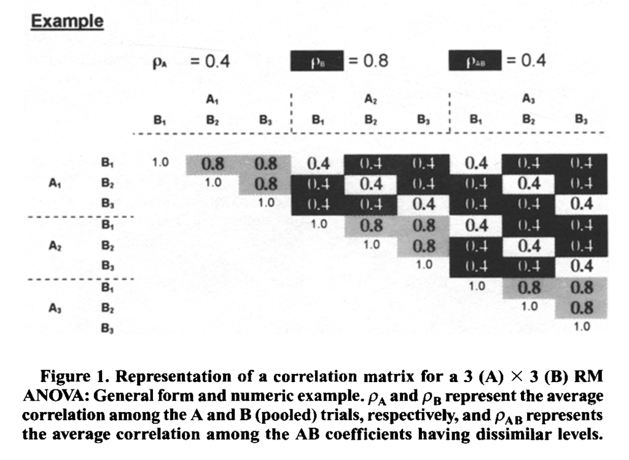

Variances were set to 1 (so all covariance matrices in their simulations were identical). In this specific example, the white fields are related to the correlation for the A main effect (these cells have the same level for B, but different levels of A). The grey cells are related to the main effect of B (the cells have the same level of A, but different levels of B). Finally, the black cells are related to the AxB interaction (they have different levels of A and B). The diagonal (all 1) relate to cells with the same levels of A and B.

Potvin & Schulz (2000) examine power for 2x2 within ANOVA designs and develop approximations of the error variance. For a design with 2 within factors (A and B) these are:

For the main effect of A: $\sigma _ { e } ^ { 2 } = \sigma ^ { 2 } ( 1 - \overline { \rho } _ { A } ) + \sigma ^ { 2 } ( q - 1 ) ( \overline { \rho } _ { B } - \overline { \rho } _ { AB } )$

For the main effectof B: $\sigma _ { e } ^ { 2 } = \sigma ^ { 2 } ( 1 - \overline { \rho } _ { B } ) + \sigma ^ { 2 } ( p - 1 ) ( \overline { \rho } _ { A } - \overline { \rho } _ { A B } )$

For the interaction between A and B: $\sigma _ { e } ^ { 2 } = \sigma ^ { 2 } ( 1 - \rho _ { \max } ) - \sigma ^ { 2 } ( \overline { \rho } _ { \min } - \overline { \rho } _ { AB } )$

Let’s now compare the formulas in Potvin and Schutz (2000) with `Superpower` with a simple scenario.

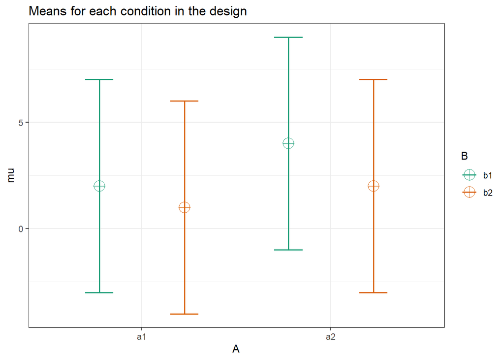

```r
mu = c(2,1,4,2)
n <- 20
sd <- 5
r <- .77
string = "2w*2w"
alpha_level <- 0.05


design_result <- ANOVA_design(design = string,
                              n = n,
                              mu = mu,
                              sd = sd,
                              r = r,
                              labelnames = labelnames,
                              plot = TRUE)
```

```r
design_result$cor_mat
```

```
##       a1_b1 a1_b2 a2_b1 a2_b2
## a1_b1  1.00  0.77  0.77  0.77
## a1_b2  0.77  1.00  0.77  0.77
## a2_b1  0.77  0.77  1.00  0.77
## a2_b2  0.77  0.77  0.77  1.00
```

```r
exact_result <- ANOVA_exact(design_result,
                            alpha_level = alpha_level,
                            verbose = FALSE)
```

Exact ANOVA Result

|  | power | partial_eta_squared | cohen_f | non_centrality |
| --- | --- | --- | --- | --- |
| A | 75.61 | 0.2917 | 0.6418 | 7.8261 |
| B | 75.61 | 0.2917 | 0.6418 | 7.8261 |
| A:B | 14.36 | 0.0438 | 0.2139 | 0.8696 |

Further, as we use the analytical solution below, the variance components should be equal to the corresponding MSE from the `ANOVA_exact` produced `anova_table` object.

```r
exact_result$aov_result$anova_table
```

```
## Anova Table (Type 3 tests)
##
## Response: y
##     num Df den Df  MSE      F      pes  Pr(>F)
## A        1     19 5.75 7.8261 0.291734 0.01149 *
## B        1     19 5.75 7.8261 0.291734 0.01149 *
## A:B      1     19 5.75 0.8696 0.043764 0.36278
## ---
## Signif. codes:  0 '***' 0.001 '**' 0.01 '*' 0.05 '.' 0.1 ' ' 1
```

We can try to use the formula in Potvin & Schutz (2000).

```r
k <- 1 #one group (because all factors are within)

rho_A <- .77 #mean r for factor A

rho_B <- .77 #mean r for factor B

rho_AB <- .77 #mean r for factor AB

alpha <- 0.05

sigma <- sd

m_A <- 2 #levels factor A

variance_e_A <- (sigma^2 * (1 - rho_A) +
  sigma^2 * (m_A - 1) * (rho_B - rho_AB) )
#Variance A
variance_e_A
```

```
## [1] 5.75
```

```r
m_B <- 2 #levels factor B

variance_e_B <- sigma^2 * (1 - rho_B) +
  sigma^2 * (m_B - 1) * (rho_A - rho_AB)
#Variance B
variance_e_B
```

```
## [1] 5.75
```

```r
variance_e_AB <-
  (sigma ^ 2 * (1 - max(rho_A, rho_B)) -
     sigma ^ 2 * (min(rho_A,rho_B) - rho_AB))
#Variance AB
variance_e_AB
```

```
## [1] 5.75
```

```r
#Create a mean matrix
mean_mat <- t(matrix(mu, nrow = m_B,ncol = m_A))
mean_mat
```

```
##      [,1] [,2]
## [1,]    2    1
## [2,]    4    2
```

```r
# Potvin & Schutz, 2000, formula 2, p. 348
# For main effect A
lambda_A <-
  (n * m_A * sum((rowMeans(mean_mat) -
                   mean(rowMeans(mean_mat))) ^ 2) ) / variance_e_A
  lambda_A
```

```
## [1] 7.826087
```

```r
#calculate degrees of freedom 1 - ignoring the sphericity correction
df1 <- (m_A - 1)

df2 <- (n - k) * (m_A - 1) #calculate degrees of freedom 2

F_critical <- qf(alpha, # critical F-vaue
                 df1,
                 df2,
                 lower.tail = FALSE)

pow_A <- pf(qf(alpha, #power
             df1,
             df2,
             lower.tail = FALSE),
          df1,
          df2,
          lambda_A,
          lower.tail = FALSE)
pow_A*100
```

```
## [1] 75.61412
```

```r
lambda_B <-
  n * m_B * sum((colMeans(mean_mat) -
                   mean(colMeans(mean_mat))) ^ 2) / variance_e_B
lambda_B
```

```
## [1] 7.826087
```

```r
df1 <- (m_B - 1) #calculate degrees of freedom 1

df2 <- (n - k) * (m_B - 1) #calculate degrees of freedom 2

F_critical <- qf(alpha, # critical F-vaue
                 df1,
                 df2,
                 lower.tail = FALSE)

pow_B <- pf(qf(alpha, #power
             df1,
             df2,
             lower.tail = FALSE),
          df1,
          df2,
          lambda_B,
          lower.tail = FALSE)


pow_B*100
```

```
## [1] 75.61412
```

```r
#Peform double summation courtesy of Andrew Vigotsky
term <- 0
for (i in 1:nrow(mean_mat)) {
  for (j in 1:ncol(mean_mat)) {
    term <- (term + (mean_mat[i,j] -
                       mean(mean_mat[i,]) -
                       mean(mean_mat[,j]) + mean(mean_mat))^2)
  }
}
term
```

```
## [1] 0.25
```

```r
#Calculate lambda for interaction term
lambda_AB <- n*term/variance_e_AB
lambda_AB
```

```
## [1] 0.8695652
```

```r
df1 <- (m_A - 1) * (m_B - 1)  #calculate degrees of freedom 1
df2 <-
(n - k) * (m_A - 1) * (m_B - 1) #calculate degrees of freedom 2
F_critical <- qf(alpha, # critical F-vaue
df1,
df2,
lower.tail = FALSE)

pow_AB <- pf(qf(alpha, #power
df1,
df2,
lower.tail = FALSE),
df1,
df2,
lambda_AB,
lower.tail = FALSE)

pow_AB*100
```

```
## [1] 14.36376
```

We can now compile all the analytical results into a single table, and see that the results match those from `ANOVA_exact`.

Analytical Result

| variance | lambda | power |
| --- | --- | --- |
| 5.75 | 7.8260870 | 75.61412 |
| 5.75 | 7.8260870 | 75.61412 |
| 5.75 | 0.8695652 | 14.36376 |

And we can see in the simple scenario matches `ANOVA_exact` and `ANOVA_power` output.

Let’s now extend to one of the simlations presented by Potvin and Schultz with a 3x3 solution.

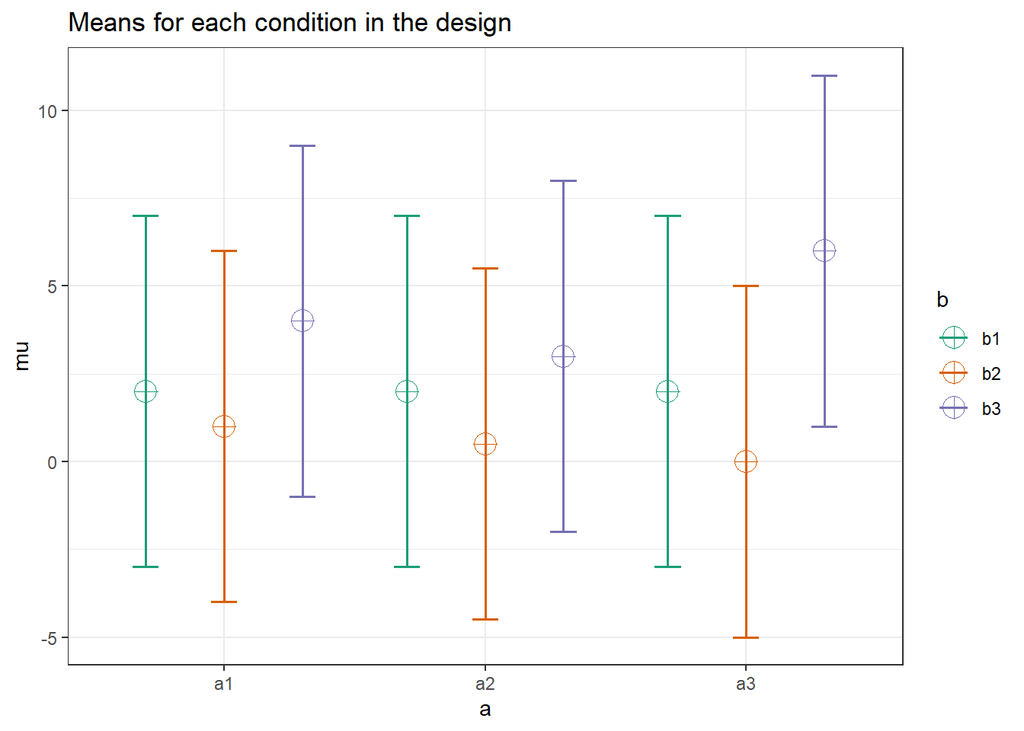

```r
mu = c(2,1,4,
       2,.5,3,
       2,0,6)
n <- 20
sd <- 5
r <- c(1.0,0.8,0.8,0.4,0.4,0.4,0.4,0.4,0.4,
       0.8,1.0,0.8,0.4,0.4,0.4,0.4,0.4,0.4,
       0.8,0.8,1.0,0.4,0.4,0.4,0.4,0.4,0.4,
       0.4,0.4,0.4,1.0,0.8,0.8,0.4,0.4,0.4,
       0.4,0.4,0.4,0.8,1.0,0.8,0.4,0.4,0.4,
       0.4,0.4,0.4,0.8,0.8,1.0,0.4,0.4,0.4,
       0.4,0.4,0.4,0.4,0.4,0.4,1.0,0.8,0.8,
       0.4,0.4,0.4,0.4,0.4,0.4,0.8,1.0,0.8,
       0.4,0.4,0.4,0.4,0.4,0.4,0.8,0.8,1.0)


string = "3w*3w"
alpha_level <- 0.05

design_result <- ANOVA_design(design = string,
                              n = n,
                              mu = mu,
                              sd = sd,
                              r = r,
                              plot = TRUE)
```

```r
design_result$cor_mat
```

```
##       a1_b1 a1_b2 a1_b3 a2_b1 a2_b2 a2_b3 a3_b1 a3_b2 a3_b3
## a1_b1   1.0   0.8   0.8   0.4   0.4   0.4   0.4   0.4   0.4
## a1_b2   0.8   1.0   0.8   0.4   0.4   0.4   0.4   0.4   0.4
## a1_b3   0.8   0.8   1.0   0.4   0.4   0.4   0.4   0.4   0.4
## a2_b1   0.4   0.4   0.4   1.0   0.8   0.8   0.4   0.4   0.4
## a2_b2   0.4   0.4   0.4   0.8   1.0   0.8   0.4   0.4   0.4
## a2_b3   0.4   0.4   0.4   0.8   0.8   1.0   0.4   0.4   0.4
## a3_b1   0.4   0.4   0.4   0.4   0.4   0.4   1.0   0.8   0.8
## a3_b2   0.4   0.4   0.4   0.4   0.4   0.4   0.8   1.0   0.8
## a3_b3   0.4   0.4   0.4   0.4   0.4   0.4   0.8   0.8   1.0
```

The design now matches the correlation matrix in Figure 1 of Potvin and Schultz.

And we can estimate power with `ANOVA_exact`.

```r
exact_result <- ANOVA_exact(design_result,
                            alpha_level = alpha_level,
                            verbose = FALSE)
```

Exact ANOVA Result

|  | power | partial_eta_squared | cohen_f | non_centrality |
| --- | --- | --- | --- | --- |
| a | 9.44 | 0.0156 | 0.1260 | 0.6032 |
| b | 100.00 | 0.7021 | 1.5352 | 89.5556 |
| a:b | 90.09 | 0.1779 | 0.4652 | 16.4444 |

Further, as we use the analytical solution below, the variance components should be equal to the corresponding MSE from the `ANOVA_exact` produced `anova_table` object.

```r
exact_result$aov_result$anova_table
```

```
## Anova Table (Type 3 tests)
##
## Response: y
##     num Df den Df MSE       F     pes    Pr(>F)
## a        2     38  35  0.3016 0.01562  0.741397
## b        2     38   5 44.7778 0.70209 1.018e-10 ***
## a:b      4     76   5  4.1111 0.17788  0.004542 **
## ---
## Signif. codes:  0 '***' 0.001 '**' 0.01 '*' 0.05 '.' 0.1 ' ' 1
```

```r
k <- 1 #one group (because all factors are within)

rho_A <- .4 #mean r for factor A

rho_B <- .8 #mean r for factor B

rho_AB <- .4 #mean r for factor AB

alpha <- 0.05

sigma <- sd

m_A <- 3 #levels factor A

variance_e_A <- sigma^2 * (1 - rho_A) +
  sigma^2 * (m_A - 1) * (rho_B - rho_AB)
#Variance A
variance_e_A
```

```
## [1] 35
```

```r
m_B <- 3 #levels factor B

variance_e_B <- sigma^2 * (1 - rho_B) +
  sigma^2 * (m_B - 1) * (rho_A - rho_AB)
#Variance B
variance_e_B
```

```
## [1] 5
```

```r
variance_e_AB <-
  (sigma ^ 2 * (1 - max(rho_A, rho_B)) -
     sigma ^ 2 * (min(rho_A,rho_B) - rho_AB))
#Variance AB
variance_e_AB
```

```
## [1] 5
```

```r
#Create a mean matrix
mean_mat <- t(matrix(mu, nrow = m_B,ncol = m_A))
mean_mat
```

```
##      [,1] [,2] [,3]
## [1,]    2  1.0    4
## [2,]    2  0.5    3
## [3,]    2  0.0    6
```

```r
# Potvin & Schutz, 2000, formula 2, p. 348
# For main effect A
lambda_A <-
  (n * m_A * sum((rowMeans(mean_mat) -
                   mean(rowMeans(mean_mat))) ^ 2) ) / variance_e_A
  lambda_A
```

```
## [1] 0.6031746
```

```r
#calculate degrees of freedom 1 - ignoring the sphericity correction
df1 <- (m_A - 1)

df2 <- (n - k) * (m_A - 1) #calculate degrees of freedom 2

F_critical <- qf(alpha, # critical F-vaue
                 df1,
                 df2,
                 lower.tail = FALSE)

pow_A <- pf(qf(alpha, #power
             df1,
             df2,
             lower.tail = FALSE),
          df1,
          df2,
          lambda_A,
          lower.tail = FALSE)
pow_A*100
```

```
## [1] 9.441726
```

```r
lambda_B <-
  n * m_B * sum((colMeans(mean_mat) -
                   mean(colMeans(mean_mat))) ^ 2) / variance_e_B
lambda_B
```

```
## [1] 89.55556
```

```r
df1 <- (m_B - 1) #calculate degrees of freedom 1

df2 <- (n - k) * (m_B - 1) #calculate degrees of freedom 2

F_critical <- qf(alpha, # critical F-vaue
                 df1,
                 df2,
                 lower.tail = FALSE)

pow_B <- pf(qf(alpha, #power
             df1,
             df2,
             lower.tail = FALSE),
          df1,
          df2,
          lambda_B,
          lower.tail = FALSE)


pow_B*100
```

```
## [1] 100
```

```r
#Peform double summation courtesy of Andrew Vigotsky
term <- 0
for (i in 1:nrow(mean_mat)) {
  for (j in 1:ncol(mean_mat)) {
    term <- ((term + (mean_mat[i,j] -
                        mean(mean_mat[i,]) -
                        mean(mean_mat[,j]) + mean(mean_mat))^2))
  }
}
term
```

```
## [1] 4.111111
```

```r
#Calculate lambda for interaction term
lambda_AB <- n*term/variance_e_AB
lambda_AB
```

```
## [1] 16.44444
```

```r
df1 <- (m_A - 1) * (m_B - 1)  #calculate degrees of freedom 1
df2 <-
(n - k) * (m_A - 1) * (m_B - 1) #calculate degrees of freedom 2
F_critical <- qf(alpha, # critical F-vaue
df1,
df2,
lower.tail = FALSE)

pow_AB <- pf(qf(alpha, #power
df1,
df2,
lower.tail = FALSE),
df1,
df2,
lambda_AB,
lower.tail = FALSE)

pow_AB*100
```

```
## [1] 90.09263
```

Again, when we compile all the analytical results into a single table we can see that the results match those from `ANOVA_exact`.

Analytical Result

| variance | lambda | power |
| --- | --- | --- |
| 35 | 0.6031746 | 9.441726 |
| 5 | 89.5555556 | 100.000000 |
| 5 | 16.4444444 | 90.092634 |